# Tensors in Action: From Element-wise Math to Matrix Multiplication in PyTorch

A hands-on guide to tensor operations in PyTorch covering common element-wise operations, statistical aggregations, NaN detection, the vector dot product, matrix multiplication with torch.matmul and the @ operator, singular value decomposition (SVD), and visualising a 3D saddle surface with torch.meshgrid and matplotlib.

pytorch

neural-networks

Author

Mei-Chin Pang

Published

March 7, 2026

This notebook provides a hands-on guide to tensor operations in PyTorch, from basic element-wise math to matrix multiplication.

- What are the common element-wise tensor operations?
- How do statistical and aggregation operations work across dimensions?
- How can we detect `NaN` values with `torch.isnan()`?
- What is the vector dot product and how does `torch.dot()` work?
- How does matrix multiplication work with `torch.matmul()` and the `@` operator?
- How does singular value decomposition work with `torch.linalg.svd()`?
- How can we visualise a 3D saddle surface using `torch.meshgrid` and `matplotlib`?

# Common Element-wise Tensor Operations

Element-wise operations apply a function independently to each element of a tensor, producing an output tensor of the same shape. These operations are vectorised in PyTorch, meaning they run efficiently on the entire tensor without explicit loops. The table below summarises some of the most commonly used element-wise functions.

| Function | What it does |
| --- | --- |
| `torch.exp(a)` | Computes $e^x$ for each element |
| `torch.log(a)` | Computes the natural logarithm ($\ln x$) for each element |
| `torch.sin(a)` | Computes the sine of each element (in radians) |
| `torch.arctan(a)` | Computes the inverse tangent (arctan) of each element |
| `torch.abs(a)` | Returns the absolute value of each element |
| `torch.square(a)` | Squares each element ($x^2$) |
| `torch.sqrt(a)` | Computes the square root of each element ($\sqrt{x}$) |
| `torch.ceil(a)` | Rounds each element up to the nearest integer |
| `torch.round(a)` | Rounds each element to the nearest integer |
| `torch.clip(a, min, max)` | Clamps each element to the range `[min, max]` |

```python
import torch
import matplotlib.pyplot as plt
```

```python
a = torch.randn(2,3)
print("Original tensor a:")
print(a)
print("-"*79)

print("exp =", torch.exp(a))
print("-"*79)

print("log =", torch.log(a))
print("-"*79)

print("sin =", torch.sin(a))
print("-"*79)

print("arctan =", torch.arctan(a))
print("-"*79)
```

```
Original tensor a:
tensor([[ 1.2598, -0.0041,  1.3176],
        [-0.5203, -0.5858,  0.0835]])
-------------------------------------------------------------------------------
exp = tensor([[3.5248, 0.9959, 3.7344],
        [0.5944, 0.5567, 1.0870]])
-------------------------------------------------------------------------------
log = tensor([[ 0.2310,     nan,  0.2758],
        [    nan,     nan, -2.4833]])
-------------------------------------------------------------------------------
sin = tensor([[ 0.9520, -0.0041,  0.9681],
        [-0.4971, -0.5529,  0.0834]])
-------------------------------------------------------------------------------
arctan = tensor([[ 0.8999, -0.0041,  0.9216],
        [-0.4797, -0.5299,  0.0833]])
-------------------------------------------------------------------------------
```

```python
print("abs =", torch.abs(a))
print("-"*79)

print("square =", torch.square(a))
print("-"*79)

print("sqrt =", torch.sqrt(a))
print("-"*79)

print("ceil =", torch.ceil(a))
print("-"*79)

print("round =", torch.round(a))
print("-"*79)

print("clip =", torch.clip(a, 0.1, 0.9))
```

```
abs = tensor([[1.2598, 0.0041, 1.3176],
        [0.5203, 0.5858, 0.0835]])
-------------------------------------------------------------------------------
square = tensor([[1.5871e+00, 1.6864e-05, 1.7360e+00],
        [2.7068e-01, 3.4314e-01, 6.9662e-03]])
-------------------------------------------------------------------------------
sqrt = tensor([[1.1224,    nan, 1.1479],
        [   nan,    nan, 0.2889]])
-------------------------------------------------------------------------------
ceil = tensor([[2., -0., 2.],
        [-0., -0., 1.]])
-------------------------------------------------------------------------------
round = tensor([[ 1., -0.,  1.],
        [-1., -1.,  0.]])
-------------------------------------------------------------------------------
clip = tensor([[0.9000, 0.1000, 0.9000],
        [0.1000, 0.1000, 0.1000]])
```

# Statistical and Aggregation Operations

Statistical and aggregation operations reduce a tensor along one or more dimensions, summarising its values into means, sums, extrema, and other descriptive statistics. All functions below accept an optional `dim` argument to operate along a specific dimension; without `dim`, they reduce over the entire tensor. The table below lists the most commonly used aggregation functions in PyTorch.

| Function | What it does |
| --- | --- |
| `torch.mean(a, dim)` | Computes the arithmetic mean along a dimension |
| `torch.std(a, dim)` | Computes the standard deviation along a dimension |
| `torch.var(a, dim)` | Computes the variance along a dimension |
| `torch.median(a, dim)` | Returns the median value (and indices) along a dimension |
| `torch.sum(a, dim)` | Sums all elements along a dimension |
| `torch.prod(a, dim)` | Computes the product of all elements along a dimension |
| `torch.cumsum(a, dim)` | Computes the cumulative sum along a dimension |
| `torch.cumprod(a, dim)` | Computes the cumulative product along a dimension |
| `torch.min(a, dim)` | Returns the minimum value (and indices) along a dimension |
| `torch.max(a, dim)` | Returns the maximum value (and indices) along a dimension |
| `torch.argmin(a, dim)` | Returns the index of the minimum value along a dimension |
| `torch.argmax(a, dim)` | Returns the index of the maximum value along a dimension |
| `torch.norm(a, dim)` | Computes the $L^p$ norm along a dimension (default $p=2$) |
| `torch.quantile(a, q, dim)` | Computes the $q$-th quantile along a dimension |

For a 2D tensor with shape `(m, n)`, setting `dim=0` reduces **along the rows** (the first axis), collapsing `m` rows into a single row. The result has shape `(n,)`, which means one value per column, computed from all `m` entries in that column. For example, `torch.mean(a, dim=0)` on a `(3, 4)` tensor returns 4 values: the mean of each column across the 3 rows.

```python
a = torch.randn(3, 4)
print("Tensor a:")
print(a)
print("-"*79)

print("mean (dim=0):")
print(torch.mean(a, dim=0))
print("-"*79)

print("std (dim=0):")
print(torch.std(a, dim=0))
print("-"*79)

print("var (dim=0):")
print(torch.var(a, dim=0))
print("-"*79)

print("median (dim=0):")
print(torch.median(a, dim=0))
print("-"*79)

print("sum (dim=0):")
print(torch.sum(a, dim=0))
print("-"*79)

print("prod (dim=0):")
print(torch.prod(a, dim=0))
print("-"*79)
```

```
Tensor a:
tensor([[-0.2427,  0.2384, -0.1037,  0.8094],
        [ 0.1877, -1.7584,  1.7207, -2.3809],
        [ 0.6550, -0.2082,  1.6822,  0.6771]])
-------------------------------------------------------------------------------
mean (dim=0):
tensor([ 0.2000, -0.5761,  1.0997, -0.2981])
-------------------------------------------------------------------------------
std (dim=0):
tensor([0.4490, 1.0480, 1.0424, 1.8050])
-------------------------------------------------------------------------------
var (dim=0):
tensor([0.2016, 1.0983, 1.0865, 3.2579])
-------------------------------------------------------------------------------
median (dim=0):
torch.return_types.median(
values=tensor([ 0.1877, -0.2082,  1.6822,  0.6771]),
indices=tensor([1, 2, 2, 2]))
-------------------------------------------------------------------------------
sum (dim=0):
tensor([ 0.6000, -1.7282,  3.2992, -0.8944])
-------------------------------------------------------------------------------
prod (dim=0):
tensor([-0.0298,  0.0873, -0.3001, -1.3049])
-------------------------------------------------------------------------------
```

```python
print("cumsum (dim=0):")
print(torch.cumsum(a, dim=0))
print("-"*79)

print("cumprod (dim=0):")
print(torch.cumprod(a, dim=0))
print("-"*79)

print("min (dim=0):")
print(torch.min(a, dim=0))
print("-"*79)

print("max (dim=0):")
print(torch.max(a, dim=0))
print("-"*79)

print("argmin (dim=0):")
print(torch.argmin(a, dim=0))
print("-"*79)

print("argmax (dim=0):")
print(torch.argmax(a, dim=0))
print("-"*79)

print("norm (dim=0):")
print(torch.norm(a, dim=0))
print("-"*79)

print("quantile (q=0.5, dim=0):")
print(torch.quantile(a, 0.5, dim=0))
```

```
cumsum (dim=0):
tensor([[-0.2427,  0.2384, -0.1037,  0.8094],
        [-0.0550, -1.5200,  1.6170, -1.5715],
        [ 0.6000, -1.7282,  3.2992, -0.8944]])
-------------------------------------------------------------------------------
cumprod (dim=0):
tensor([[-0.2427,  0.2384, -0.1037,  0.8094],
        [-0.0456, -0.4192, -0.1784, -1.9271],
        [-0.0298,  0.0873, -0.3001, -1.3049]])
-------------------------------------------------------------------------------
min (dim=0):
torch.return_types.min(
values=tensor([-0.2427, -1.7584, -0.1037, -2.3809]),
indices=tensor([0, 1, 0, 1]))
-------------------------------------------------------------------------------
max (dim=0):
torch.return_types.max(
values=tensor([0.6550, 0.2384, 1.7207, 0.8094]),
indices=tensor([2, 0, 1, 0]))
-------------------------------------------------------------------------------
argmin (dim=0):
tensor([0, 1, 0, 1])
-------------------------------------------------------------------------------
argmax (dim=0):
tensor([2, 0, 1, 0])
-------------------------------------------------------------------------------
norm (dim=0):
tensor([0.7233, 1.7866, 2.4086, 2.6043])
-------------------------------------------------------------------------------
quantile (q=0.5, dim=0):
tensor([ 0.1877, -0.2082,  1.6822,  0.6771])
```

# Detecting NaN Values with `torch.isnan()`

`torch.isnan(input)` returns a **boolean tensor** of the same shape, where each element is `True` if the corresponding value is `NaN` (Not a Number), and `False` otherwise.

**Why NaN appears here**

`torch.sqrt(a)` computes the square root of each element. Since `a` was created with `torch.randn()`, some elements may be **negative**. The square root of a negative real number is undefined, so PyTorch returns `NaN` for those entries.

```python
b = torch.sqrt(a)
print(b)
print(torch.isnan(b))
```

```
tensor([[   nan, 0.4883,    nan, 0.8997],
        [0.4333,    nan, 1.3117,    nan],
        [0.8093,    nan, 1.2970, 0.8229]])
tensor([[ True, False,  True, False],
        [False,  True, False,  True],
        [False,  True, False, False]])
```

# Vector Dot Product with `torch.dot()`

- The dot product, named after the dot symbol ($\cdot$) used to denote it, is an operation on vectors that takes two vectors and returns a single number (a scalar), unlike addition or scalar multiplication which return vectors.
- The dot product multiplies corresponding elements and sums the results, producing a single scalar:

$$a \cdot b = a_1 b_1 + a_2 b_2 + a_3 b_3 = \sum_{i=1}^{n} a_i b_i$$

- It is also called the **scalar product** for this reason, and is a specific case of a more general operation known as the **inner product**.
- `torch.dot(a, b)` computes the dot product of two 1D tensors. The `@` operator also works for 1D inputs and produces the same result.
- The result is a **0D scalar tensor** (not a 1D tensor).
- The dot product is closely related to matrix multiplication: for 1D vectors, `a @ b` is equivalent to `torch.dot(a, b)`, whereas for 2D matrices `@` performs `torch.matmul`.

**Example:**

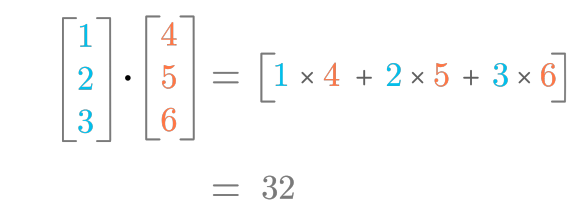

An Illustration of Vector Dot Product

```python
a = torch.randn(3)   # shape (3,)
b = torch.randn(3)   # shape (3,)
torch.dot(a, b)      # scalar
a @ b                # scalar
```

```python
a = torch.randn(3)
print("Tensor a:")
print(a)
print("-"*79)

b = torch.randn(3)
print("Tensor b:")
print(b)
print("-"*79)

print("Dot product using torch.dot:")
print(torch.dot(a, b))
print("-"*79)

print("Dot product using @ operator:")
print(a @ b)
```

```
Tensor a:
tensor([-2.1615,  1.2231,  2.0254])
-------------------------------------------------------------------------------
Tensor b:
tensor([1.3500, 0.6283, 0.7026])
-------------------------------------------------------------------------------
Dot product using torch.dot:
tensor(-0.7265)
-------------------------------------------------------------------------------
Dot product using @ operator:
tensor(-0.7265)
```

# Matrix Multiplication with `torch.matmul()` and the `@` Operator

- Matrix multiplication requires the inner dimensions to match: `(m, k) × (k, n) → (m, n)`. Here `a` is `(2, 4)` and `b` is `(4, 3)`, so the inner dimension is 4 and the result is `(2, 3)`. Each element $c_{ij}$ is the dot product of row $i$ of `a` and column $j$ of `b`:

$$c_{ij} = \sum_{k=1}^{4} a_{ik} \cdot b_{kj}$$

For example:

- $c_{11} = a_{11}b_{11} + a_{12}b_{21} + a_{13}b_{31} + a_{14}b_{41}$ (row 1 of `a` $\cdot$ column 1 of `b`)
- $c_{22} = a_{21}b_{12} + a_{22}b_{22} + a_{23}b_{32} + a_{24}b_{42}$ (row 2 of `a` $\cdot$ column 2 of `b`)

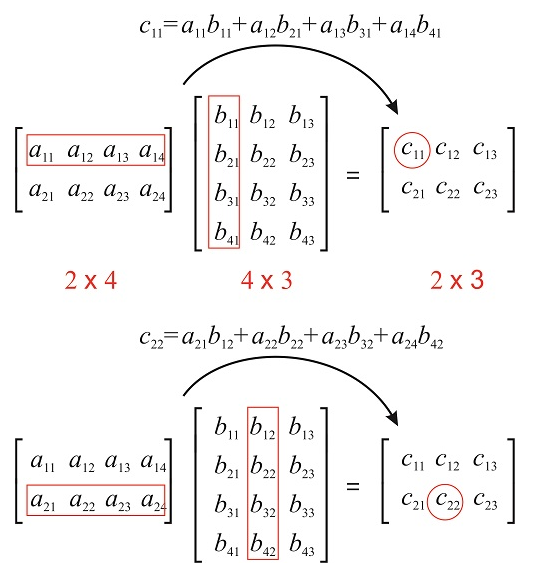

An Illustration of Matrix Multiplication

- `torch.matmul(a, b)` performs **matrix multiplication** between two tensors. The `@` operator is a shorthand that does the same thing.
- This is **not** element-wise multiplication. For that, use `a * b` or `torch.mul(a, b)`.

**`torch.matmul` vs `@` vs other options**

| Method | Description |
| --- | --- |
| `torch.matmul(a, b)` | General-purpose matrix multiplication; supports broadcasting and batched inputs |
| `a @ b` | Operator shorthand for `torch.matmul` |
| `torch.mm(a, b)` | Strictly 2D matrix multiplication only (no broadcasting) |

**Example:**

```python
a = torch.randn(2, 4)   # shape (2, 4)
b = torch.randn(4, 3)   # shape (4, 3)
torch.matmul(a, b)      # shape (2, 3)
a @ b                   # shape (2, 3)
```

```python
a = torch.randn(2, 4)
print("Tensor a (2x4):")
print(a)
print("-"*79)

b = torch.randn(4, 3)
print("Tensor b (4x3):")
print(b)
print("-"*79)

print("Matrix multiplication using torch.matmul (2x3):")
print(torch.matmul(a, b))
print("-"*79)

print("Matrix multiplication using @ operator (2x3):")
print(a @ b)
```

```
Tensor a (2x4):
tensor([[ 1.2194,  1.3448,  0.2941,  1.6100],
        [ 0.1784, -0.3189, -1.0860,  0.6163]])
-------------------------------------------------------------------------------
Tensor b (4x3):
tensor([[-2.2816,  1.3947, -0.4564],
        [-0.3457,  0.7439, -1.4234],
        [ 1.5466,  1.4533,  0.9812],
        [ 0.6984,  0.5244,  0.6321]])
-------------------------------------------------------------------------------
Matrix multiplication using torch.matmul (2x3):
tensor([[-1.6678,  3.9728, -1.1646],
        [-1.5460, -1.2436, -0.3036]])
-------------------------------------------------------------------------------
Matrix multiplication using @ operator (2x3):
tensor([[-1.6678,  3.9728, -1.1646],
        [-1.5460, -1.2436, -0.3036]])
```

# Singular Value Decomposition (SVD) with `torch.linalg.svd()`

## What is SVD?

- SVD breaks any matrix into three simpler matrices: a rotation ($U$), a scaling (diagonal $S$), and another rotation ($V^H$), so that $A = U \cdot \text{diag}(S) \cdot V^H$.
- The singular values in $S$ tell you how much each corresponding direction is stretched, ranked from most to least important. The first value captures the most variance.
- This makes SVD a powerful tool for tasks like dimensionality reduction and low-rank approximation, since you can drop the smallest singular values to get a compact approximation of the original matrix.
- **U** and **Vh** are orthogonal matrices, meaning $U^T U = I$ and $V^H V = I$.
- `torch.linalg.svd(a)` computes the **Singular Value Decomposition** of a matrix $A$, factorizing it into three matrices:

$$A = U \cdot \text{diag}(S) \cdot V^H$$

**Example:**

```python
a = torch.randn(3, 3)   # shape (3, 3)
torch.linalg.svd(a)     # returns (U, S, Vh)
```

The output is a named tuple with three components:

| Component | Shape | Meaning |
| --- | --- | --- |
| **U** | `(m, m)` → `(3, 3)` | Left singular vectors: orthogonal matrix whose columns are eigenvectors of $AA^T$ |
| **S** | `(min(m, n),)` → `(3,)` | Singular values: non-negative values in descending order |
| **Vh** | `(n, n)` → `(3, 3)` | Right singular vectors (conjugate-transposed): orthogonal matrix whose rows are eigenvectors of $A^T A$ |

## Verifying: Reconstruct $A$ from $U$, $S$, and $V^H$

We can manually verify the decomposition by reconstructing the original matrix from its SVD components. If the decomposition is correct, $U \cdot \text{diag}(S) \cdot V^H$ should equal the original matrix $A$ (up to floating-point precision).

```python
a = torch.randn(3, 3)
print("Tensor a:")
print(a)
print("-"*79)

# Compute SVD
U, S, Vh = torch.linalg.svd(a)
print("U:")
print(U)
print("-"*79)

print("S:")
print(S)
print("-"*79)

print("Vh:")
print(Vh)
print("-"*79)

# Reconstruct A from U, S, Vh
a_reconstructed = U @ torch.diag(S) @ Vh
print("Reconstructed A = U @ diag(S) @ Vh:")
print(a_reconstructed)
print("-"*79)

# Verify: difference should be near zero
print("Difference (A - reconstructed A):")
print(a - a_reconstructed)
print("-"*79)
print("All close?", torch.allclose(a, a_reconstructed))
```

```
Tensor a:
tensor([[ 0.6534,  1.1631, -1.6241],
        [ 1.0289, -2.0669,  1.3471],
        [ 0.8866,  0.8535, -0.8044]])
-------------------------------------------------------------------------------
U:
tensor([[ 0.5794,  0.5063, -0.6387],
        [-0.7382,  0.6581, -0.1480],
        [ 0.3454,  0.5573,  0.7550]])
-------------------------------------------------------------------------------
S:
tensor([3.3357, 1.5783, 0.3258])
-------------------------------------------------------------------------------
Vh:
tensor([[-0.0224,  0.7478, -0.6635],
        [ 0.9517, -0.1874, -0.2433],
        [ 0.3063,  0.6369,  0.7075]])
-------------------------------------------------------------------------------
Reconstructed A = U @ diag(S) @ Vh:
tensor([[ 0.6534,  1.1631, -1.6241],
        [ 1.0289, -2.0669,  1.3471],
        [ 0.8866,  0.8535, -0.8044]])
-------------------------------------------------------------------------------
Difference (A - reconstructed A):
tensor([[-1.1921e-07,  2.3842e-07, -2.3842e-07],
        [-1.1921e-07,  0.0000e+00,  0.0000e+00],
        [-1.7881e-07,  1.1921e-07, -5.9605e-08]])
-------------------------------------------------------------------------------
All close? True
```

## Manual SVD Computation without `torch.linalg.svd`

The SVD of a real matrix $A$ can be derived from the eigendecomposition of $A^T A$:

1. Compute $A^T A$: a symmetric positive semi-definite matrix of shape `(n, n)`
2. Eigendecompose $A^T A = V \Lambda V^T$, where $\Lambda = \text{diag}(\lambda_1, \lambda_2, \ldots)$
3. The singular values are $\sigma_i = \sqrt{\lambda_i}$, sorted in descending order
4. The columns of $V$ (reordered by descending $\sigma_i$) give $V^H = V^T$
5. Compute each column of $U$ as: $u_i = \frac{1}{\sigma_i} A v_i$

```python
# Use the same tensor a from the previous cell
print("Original tensor a:")
print(a)
print("-"*79)

# Step 1: Compute A^T A
AtA = a.T @ a
print("Step 1: Compute A^T A")
print(AtA)
print("-"*79)

# Step 2: Eigendecompose A^T A - eigenvalues and eigenvectors
eigenvalues, V = torch.linalg.eigh(AtA)
print("Step 2: Eigenvalues of A^T A")
print(eigenvalues)
print("Eigenvectors V (columns):")
print(V)
print("-"*79)

# Step 3: Sort eigenvalues in descending order
print("Step 3: Sort eigenvalues in descending order")
print("Original eigenvalues:", eigenvalues)
sort_idx = torch.argsort(eigenvalues, descending=True)
print("Sorted indices:", sort_idx)
eigenvalues = eigenvalues[sort_idx]
print("Sorted eigenvalues:", eigenvalues)
V = V[:, sort_idx]
print("Sorted eigenvectors V (columns):")
print(V)
print("-"*79)

# Step 4: Singular values = sqrt(eigenvalues)
S_manual = torch.sqrt(eigenvalues)
print("Step 4: Singular values S (sorted descending):")
print(S_manual)
print("-"*79)

# Step 5: Vh = V^T
Vh_manual = V.T
print("Step 5: Vh = V^T:")
print(Vh_manual)
print("-"*79)
```

```
Original tensor a:
tensor([[ 0.6534,  1.1631, -1.6241],
        [ 1.0289, -2.0669,  1.3471],
        [ 0.8866,  0.8535, -0.8044]])
-------------------------------------------------------------------------------
Step 1: Compute A^T A
tensor([[ 2.2716, -0.6098, -0.3885],
        [-0.6098,  6.3533, -5.3598],
        [-0.3885, -5.3598,  5.0993]])
-------------------------------------------------------------------------------
Step 2: Eigenvalues of A^T A
tensor([ 0.1062,  2.4910, 11.1271])
Eigenvectors V (columns):
tensor([[ 0.3063,  0.9517,  0.0224],
        [ 0.6369, -0.1874, -0.7478],
        [ 0.7075, -0.2433,  0.6635]])
-------------------------------------------------------------------------------
Step 3: Sort eigenvalues in descending order
Original eigenvalues: tensor([ 0.1062,  2.4910, 11.1271])
Sorted indices: tensor([2, 1, 0])
Sorted eigenvalues: tensor([11.1271,  2.4910,  0.1062])
Sorted eigenvectors V (columns):
tensor([[ 0.0224,  0.9517,  0.3063],
        [-0.7478, -0.1874,  0.6369],
        [ 0.6635, -0.2433,  0.7075]])
-------------------------------------------------------------------------------
Step 4: Singular values S (sorted descending):
tensor([3.3357, 1.5783, 0.3258])
-------------------------------------------------------------------------------
Step 5: Vh = V^T:
tensor([[ 0.0224, -0.7478,  0.6635],
        [ 0.9517, -0.1874, -0.2433],
        [ 0.3063,  0.6369,  0.7075]])
-------------------------------------------------------------------------------
```

```python
# Step 6: Compute U column by column: u_i = (1/σ_i) * A @ v_i
U_manual = torch.zeros(a.shape[0], a.shape[0])
for i in range(len(S_manual)):
    U_manual[:, i] = (a @ V[:, i]) / S_manual[i]
print("Step 6: U (computed as u_i = A v_i / σ_i):")
print(U_manual)
print("-"*79)

# Verify: reconstruct A from manual SVD
a_manual = U_manual @ torch.diag(S_manual) @ Vh_manual
print("Reconstructed A = U @ diag(S) @ Vh:")
print(a_manual)
print("-"*79)
print("All close to original?", torch.allclose(a, a_manual, atol=1e-5))
```

```
Step 6: U (computed as u_i = A v_i / σ_i):
tensor([[-0.5794,  0.5063, -0.6387],
        [ 0.7382,  0.6581, -0.1480],
        [-0.3454,  0.5573,  0.7550]])
-------------------------------------------------------------------------------
Reconstructed A = U @ diag(S) @ Vh:
tensor([[ 0.6534,  1.1631, -1.6241],
        [ 1.0289, -2.0669,  1.3471],
        [ 0.8866,  0.8535, -0.8044]])
-------------------------------------------------------------------------------
All close to original? True
```

# Visualising a Hyperbolic Paraboloid (Saddle Surface)

This section demonstrates how to construct and visualise a 3D mathematical surface from several PyTorch tensor operations. The surface plotted is a **hyperbolic paraboloid** ($z = x^2 - (y/2)^2$), which curves upward in one direction and downward in another, forming a classic saddle shape. Cross-section lines and a marked saddle point at the origin highlight the opposing curvatures. It’s a practical example of how vectorised tensor operations can efficiently evaluate a function over an entire grid without any explicit Python loops.

## How to Visualise a Surface Plot with PyTorch?

1. **Create 1D grids**: `torch.linspace(-1, 1, 100)` produces 100 evenly spaced values for $x$, and similarly for $y$ over $[-2, 2]$.
2. **Expand to 2D grids**: `torch.meshgrid(x, y, indexing="xy")` broadcasts the 1D vectors into two `(100, 100)` tensors `xx` and `yy`, where every $(x, y)$ pair on the grid is represented.
3. **Compute $z$ element-wise**: The surface equation $z = x^2 - (y/2)^2$ is evaluated for all 10 000 grid points at once using element-wise `**` (power) and `-` (subtraction). This is a **hyperbolic paraboloid**: it curves upward along the $x$-axis and downward along the $y$-axis, meeting at a **saddle point** at the origin.
4. **Plot the surface**: `ax.plot_surface` renders the 3D surface with a diverging `RdBu` colour map (red for negative $z$, blue for positive $z$).
5. **Overlay cross-sections**: Two black lines through the saddle point show the opposing curvatures:
   - **Solid** ($y = 0$): $z = x^2$, which is an upward parabola.
   - **Dashed** ($x = 0$): $z = -(y/2)^2$, which is a downward parabola.
6. **Mark the saddle point**: A red dot at $(0, 0, 0)$ highlights where the two curvatures meet.

> **Note:** A **saddle point** is a point on a surface where the curvature goes up in one direction and down in another (like the centre of a horse saddle). At that point, the surface is neither a local minimum nor a local maximum; it’s a minimum along one axis, but a maximum along the other.

In this example, the origin $(0, 0, 0)$ is the saddle point: along the $x$-axis the parabola $z = x^2$ curves upward, while along the $y$-axis the parabola $z = -(y/2)^2$ curves downward. Saddle points are important in optimisation (e.g. training neural networks) because gradient-based methods can slow down or get stuck near them, since the gradient is zero but the point is not a true minimum.

```
Meshgrid xx:
tensor([[-1.0000, -0.9798, -0.9596,  ...,  0.9596,  0.9798,  1.0000],
        [-1.0000, -0.9798, -0.9596,  ...,  0.9596,  0.9798,  1.0000],
        [-1.0000, -0.9798, -0.9596,  ...,  0.9596,  0.9798,  1.0000],
        ...,
        [-1.0000, -0.9798, -0.9596,  ...,  0.9596,  0.9798,  1.0000],
        [-1.0000, -0.9798, -0.9596,  ...,  0.9596,  0.9798,  1.0000],
        [-1.0000, -0.9798, -0.9596,  ...,  0.9596,  0.9798,  1.0000]])
-------------------------------------------------------------------------------
Meshgrid yy:
tensor([[-2.0000, -2.0000, -2.0000,  ..., -2.0000, -2.0000, -2.0000],
        [-1.9596, -1.9596, -1.9596,  ..., -1.9596, -1.9596, -1.9596],
        [-1.9192, -1.9192, -1.9192,  ..., -1.9192, -1.9192, -1.9192],
        ...,
        [ 1.9192,  1.9192,  1.9192,  ...,  1.9192,  1.9192,  1.9192],
        [ 1.9596,  1.9596,  1.9596,  ...,  1.9596,  1.9596,  1.9596],
        [ 2.0000,  2.0000,  2.0000,  ...,  2.0000,  2.0000,  2.0000]])
```

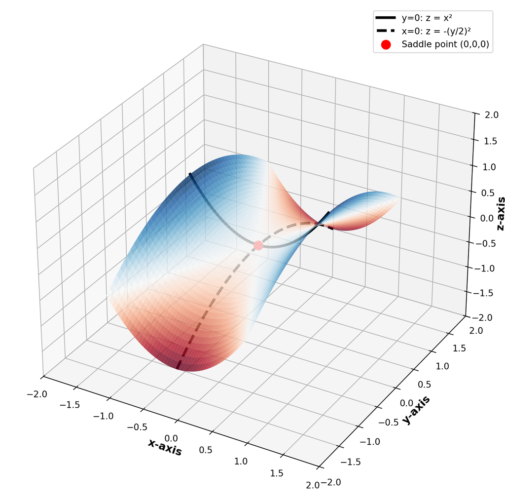

Figure 1: An example of hyperbolic paraboloid surface plot with PyTorch.

```python
# create tensors
x = torch.linspace(-1, 1, 100)
y = torch.linspace(-2, 2, 100)

# create the surface
xx, yy = torch.meshgrid(
    x, y, indexing="xy")
print("Meshgrid xx:")
print(xx)
print("-"*79)
print("Meshgrid yy:")
print(yy)

# Define a hyperbolic paraboloid surface: z = x^2 - (y/2)^2
z = xx**2 - (yy/2)**2

# xy-indexing is matching numpy
fig = plt.figure(figsize=(8,8))
ax = fig.add_subplot(111, projection="3d")
ax.set_xlim([-2, 2])
ax.set_ylim([-2, 2])
ax.set_zlim([-2, 2])
ax.set_xlabel("x-axis", fontweight="bold", fontsize=12, labelpad=1)
ax.set_ylabel("y-axis", fontweight="bold", fontsize=12, labelpad=1)
ax.set_zlabel("z-axis", fontweight="bold", fontsize=12, labelpad=0.5)
ax.plot_surface(xx, yy, z, cmap="RdBu", alpha=0.8)

# Plot lines through the saddle point at (0, 0, 0)
# Along x-axis (y=0): z = x^2  (upward parabola)
ax.plot(
    x, torch.zeros_like(x), x**2,
    color="black", linewidth=3,
    label="y=0: z = x²")

# Along y-axis (x=0): z = -(y/2)^2  (downward parabola)
ax.plot(
    torch.zeros_like(y), y, -(y/2)**2,
    color="black", linewidth=3,
    linestyle="--", label="x=0: z = -(y/2)²")

# Mark the saddle point
ax.scatter(
    [0], [0], [0], color="red", s=100, zorder=5,
    label="Saddle point (0,0,0)")

ax.legend(fontsize=10)
# ax.view_init(45, 35)
plt.tight_layout()
plt.show()
```

# References

1. PyTorch Documentation, 2024. [Tensors](https://pytorch.org/docs/stable/tensors.html). PyTorch.
2. PyTorch Documentation, 2024. [torch.matmul](https://pytorch.org/docs/stable/generated/torch.matmul.html). PyTorch.